# 对‘Spoils division rules shape aggression between natural groups’的可重复性研究

林昕、宋丹丹、万心茹、陈娟、樊富强

2023-06-12

对‘Spoils division rules shape aggression between natural groups’的可重复性研究

```r
####导入数据
pacman::p_load("tidyverse", "bruceR", "ggplot2", "ggsignif", "PropCIs")
data <- bruceR::import("./data/Dogan_Glowacki_Rusch_Data.csv", as = "data.table")
```

```
## ✔ Successfully imported: 192 obs. of 18 variables
```

```r
# 1. Convenience wrapper function for Fisher's exact test [FET]
fisher = function(A,B) {
   m = matrix(c(
    sum(A), length(A)-sum(A),
    sum(B), length(B)-sum(B)), byrow=T, nrow=2)
  print(fisher.test(m))
  print(m)
  return(fisher.test(m))
}

rFromWilcox = function(wilcoxModel, N) {
  # Function extracts effect size estimates (r's) from a given Wilcox model with N observations
  # Source: Andy Field et al. (2012): "Discovering statistics using R", SAGE, p. 665
  z <- qnorm(wilcoxModel$p.value/2)
  r <- z/sqrt(N)
  cat(wilcoxModel$data.name, "Effect Size, r = ", r)
}

wilcoxon = function(A,B) {
  # Convenience wrapper function for Wilcoxon rank-sum test [WRST]
  k = wilcox.test(A, B, exact=F, conf.int = T)
  length(A);length(B);median(A);median(B); print(k); rFromWilcox(k, length(c(A,B)))
  print("")
  print(paste("N's (A/B): ", length(A),"/", length(B), sep=""))
  print(paste("Medians (A/B): ", median(A),"/", median(B), sep=""))
}
```

```r
#如果data$Stage1.Contribution的值等于6，data$S1.Contrib将被设置为1，否则为0。
# S1阶段做出的贡献值为6，意味着在S1阶段该被试做出了贡献。
data <- data %>%
  mutate(S1.Contrib = if_else(Stage1.Contribution == 6, 1, 0))
```

#================================================================================ # 第一阶段：按实验条件和共享角色划分的贡献者比例 # 负责成员：宋丹丹、万心茹、陈娟 #================================================================================

```r
# 描述统计
table_counts <- table(data$S1.Contrib, data$Shares, data$GroupRelationship)
table_counts
```

```
## , ,  = Enmity
##
##
##     Equal High Low
##   0     9    1  20
##   1    39   15  12
##
## , ,  = Neutral
##
##
##     Equal High Low
##   0    24    2  23
##   1    24   14   9
```

```r
# 输出的table可以看到，在2（敌对或中立）× 3（分配条件：平等、高、低）情况下的贡献人数。
```

```r
S1 <- as.data.frame(matrix(nrow=6, ncol=5))
# 第1列是不同分配条件
S1[, 1] <- c("Equal", "Equal", "Low", "High", "Low", "High")
# 第2列是不同群际关系
S1[, 2] <- c("Neutral", "Enmity", "Neutral", "Neutral", "Enmity", "Enmity")
# 命名各变量
colnames(S1) <- c("ShareCondition", "GroupRelationship", "Contributors", "CI.l", "CI.u")

S1[1:6, 3] <- c(
  # Equal & Neutral
  mean(data[data$Shares == "Equal" & data$GroupRelationship == "Neutral", ]$S1.Contrib),
    # Equal & Enmity
  mean(data[data$Shares == "Equal" & data$GroupRelationship == "Enmity", ]$S1.Contrib),
    # Low & Neutral
  mean(data[data$Shares == "Low" & data$GroupRelationship == "Neutral", ]$S1.Contrib),
    # High & Neutral
  mean(data[data$Shares == "High" & data$GroupRelationship == "Neutral", ]$S1.Contrib),
    # Low & Enmity
  mean(data[data$Shares == "Low" & data$GroupRelationship == "Enmity", ]$S1.Contrib),
    # High & Enmity
  mean(data[data$Shares == "High" & data$GroupRelationship == "Enmity", ]$S1.Contrib)
)
```

```r
# 计算置信区间
S1[1,4:5] = scoreci(sum(data[data$Shares=="Equal" & data$GroupRelationship=="Neutral",]$S1.Contrib),
                    length(data[data$Shares=="Equal" & data$GroupRelationship=="Neutral",]$S1.Contrib), 0.95)$conf.int
S1[2,4:5] = scoreci(sum(data[data$Shares=="Equal" & data$GroupRelationship=="Enmity", ]$S1.Contrib),
                    length(data[data$Shares=="Equal" & data$GroupRelationship=="Enmity", ]$S1.Contrib), 0.95)$conf.int
S1[3,4:5] = scoreci(sum(data[data$Shares=="Low" & data$GroupRelationship=="Neutral",]$S1.Contrib),
                    length(data[data$Shares=="Low"   & data$GroupRelationship=="Neutral",]$S1.Contrib), 0.95)$conf.int
S1[4,4:5] = scoreci(sum(data[data$Shares=="High"  & data$GroupRelationship=="Neutral",]$S1.Contrib),
                    length(data[data$Shares=="High"  & data$GroupRelationship=="Neutral",]$S1.Contrib), 0.95)$conf.int
S1[5,4:5] = scoreci(sum(data[data$Shares=="Low"   & data$GroupRelationship=="Enmity", ]$S1.Contrib),
                    length(data[data$Shares=="Low"   & data$GroupRelationship=="Enmity", ]$S1.Contrib), 0.95)$conf.int

S1[6,4:5] = scoreci(sum(data[data$Shares=="High"  & data$GroupRelationship=="Enmity",]$S1.Contrib),length(data[data$Shares=="High"  & data$GroupRelationship=="Enmity", ]$S1.Contrib), 0.95)$conf.int
# 转换为百分比
S1.100 <- S1
S1.100[, 3:5] <- S1.100[, 3:5] * 100
```

```r
###Fisher检验 采用作者编制的fisher函数
# 对于"Equal"分享角色和"Enmity"与"Neutral"群体关系之间的Fisher精确检验
fisher_equal <- fisher(data[data$Shares=="Equal" &
                              data$GroupRelationship=="Enmity", ]$S1.Contrib,
                      data[data$Shares=="Equal" &
                              data$GroupRelationship=="Neutral", ]$S1.Contrib)
```

```
##
##  Fisher's Exact Test for Count Data
##
## data:  m
## p-value = 0.002364
## alternative hypothesis: true odds ratio is not equal to 1
## 95 percent confidence interval:
##   1.593174 12.297788
## sample estimates:
## odds ratio
##   4.263778
##
##      [,1] [,2]
## [1,]   39    9
## [2,]   24   24
```

```r
# 对于"Low"分享角色和"Enmity"与"Neutral"群体关系之间的Fisher精确检验
fisher_low <- fisher(data[data$Shares=="Low" &
                            data$GroupRelationship=="Enmity", ]$S1.Contrib,
                          data[data$Shares=="Low" &
                             data$GroupRelationship=="Neutral", ]$S1.Contrib)
```

```
##
##  Fisher's Exact Test for Count Data
##
## data:  m
## p-value = 0.595
## alternative hypothesis: true odds ratio is not equal to 1
## 95 percent confidence interval:
##  0.4739696 5.0466799
## sample estimates:
## odds ratio
##   1.523047
##
##      [,1] [,2]
## [1,]   12   20
## [2,]    9   23
```

```r
# 对于"High"分享角色和"Enmity"与"Neutral"群体关系之间的Fisher精确检验
fisher_high <- fisher(data[data$Shares=="High" &
                             data$GroupRelationship=="Enmity", ]$S1.Contrib,
                           data[data$Shares=="High" &
                             data$GroupRelationship=="Neutral", ]$S1.Contrib)
```

```
##
##  Fisher's Exact Test for Count Data
##
## data:  m
## p-value = 1
## alternative hypothesis: true odds ratio is not equal to 1
## 95 percent confidence interval:
##    0.09862608 134.58929986
## sample estimates:
## odds ratio
##   2.093765
##
##      [,1] [,2]
## [1,]   15    1
## [2,]   14    2
```

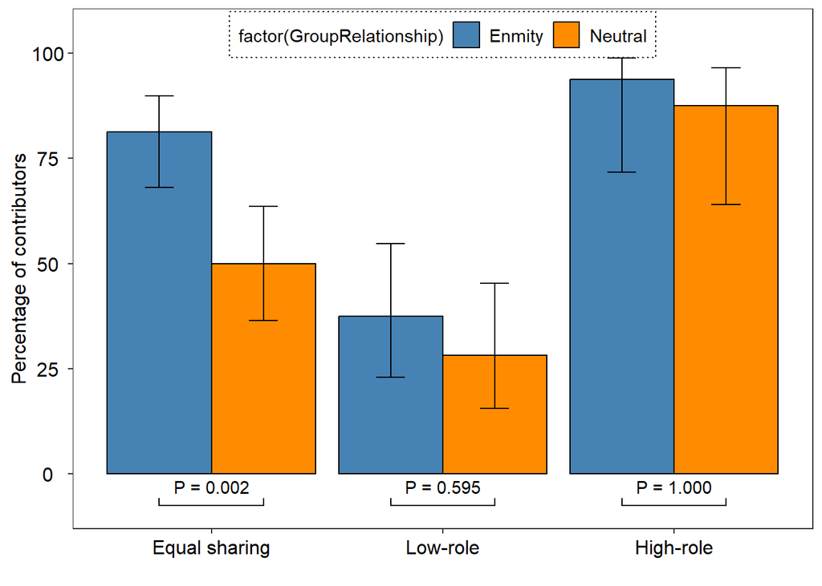

```r
# 设置图形的数据和美学映射
p1 <- ggplot(S1.100, aes(fill = factor(GroupRelationship),
                         y = Contributors, x = factor(ShareCondition,
                         levels = c("Equal", "Low", "High"),
                         labels = c("Equal sharing", "Low-role", "High-role"))))

# 设置主题样式
p1 <- p1 + theme_bw() +
  scale_fill_grey(name = "Group relation: ", start = 0.75, end = 1) +
  scale_fill_manual(values = c("steelblue", "darkorange")) +
  theme(
    panel.grid.major.x = element_blank(),
    panel.grid.major.y = element_blank(),
    panel.grid.minor.y = element_blank(),
    legend.position = c(0.5, 0.95),
    legend.background = element_rect(color = "black", fill = "white", size = 0.5, linetype = "dotted"),
    axis.text.x = element_text(colour = "black", size = 12, angle = 0, hjust = .5, vjust = .5, face = "plain"),
    axis.text.y = element_text(colour = "black", size = 12, angle = 0, hjust = .5, vjust = .5, face = "plain"),
    axis.title.y = element_text(colour = "black", size = 12, angle = 90, hjust = .5, vjust = .5, face = "plain"),
    text = element_text(size = 11),
    legend.text = element_text(size = 11),
    legend.title = element_text(size = 11),
    legend.direction = "horizontal"
  )
# 添加柱状图和误差线
p1 <- p1 + geom_bar(stat = "identity", position = "dodge", color = "black") +
  geom_errorbar(aes(ymax = CI.u, ymin = CI.l), position = position_dodge(0.9), width = 0.25)

# 设置坐标轴标签和范围
p1 <- p1 + ylab("Percentage of contributors") +
  ylim(c(-7.5, 105)) + xlab("")


# 添加显著性标记
p1 <- p1 + geom_signif(
    y_position = c(-7.5, -7.5, -7.5),
    xmin = c(0.775, 1.775, 2.775),
    xmax = c(1.225, 2.225, 3.225),
    annotation = c(
      paste("P =", format(round(fisher_equal$p.value, 3), nsmall = 3)),
      paste("P =", format(round(fisher_low$p.value, 3), nsmall = 3)),
      paste("P =", format(round(fisher_high$p.value, 3), nsmall = 3))
    ),
    tip_length = -0.02
)

print(p1)
```

#======================================================================================= # 实验2：按照实验条件和共享角色划分的条件性贡献决策 # 负责成员：樊富强、林昕 #=======================================================================================

```r
# 将被试当对手池子的不同情况（0，6，12，18, 分别对应0，1，2，3个对手做出贡献）放进策略变量中
data$Strategy <- paste(data$Stage2.OppPot0, data$Stage2.OppPot6, data$Stage2.OppPot12,data$Stage2.OppPot18, sep = "")

# 根据作者的方法，至少一次随着外群体奖池大小的增加，而从贡献到不贡献转换的受试者被归类为“Mixed”
table(ifelse(data$Strategy %in% c("6666", "0666", "0066", "0006", "0000"), data$Strategy, "Mixed"), data$GroupRelationship, data$Shares)
```

```
## , ,  = Equal
##
##
##         Enmity Neutral
##   0000       4       5
##   0006       1       5
##   0066      26      19
##   0666       5       6
##   6666       6       6
##   Mixed      6       7
##
## , ,  = High
##
##
##         Enmity Neutral
##   0000       0       0
##   0006       0       0
##   0066       1       1
##   0666       4       3
##   6666       8       8
##   Mixed      3       4
##
## , ,  = Low
##
##
##         Enmity Neutral
##   0000       4       5
##   0006       2       5
##   0066       9       9
##   0666      11       6
##   6666       3       4
##   Mixed      3       3
```